# HOMEWORK 4

This report concerns a Gradient Boosted Tree model trained on the Heart Attack dataset. A usual train/test split was performed - the explanations are executed on the test set.

# CP (Exercise 2 and 3)

Here, restecg displays the desired property (ex. 3) restecg stands for resting electrocardiographic results, which are results of a test that can detect abnormalities including arrhythmias and evidence of coronary heart disease. It is discrete, having values 0,1 or 2. Because the explanations are local, it is easy to imagine that for some groups, the test result might have a different incluence.

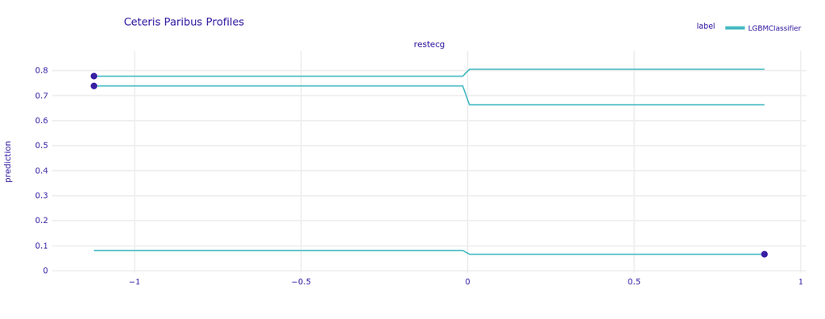

all variables

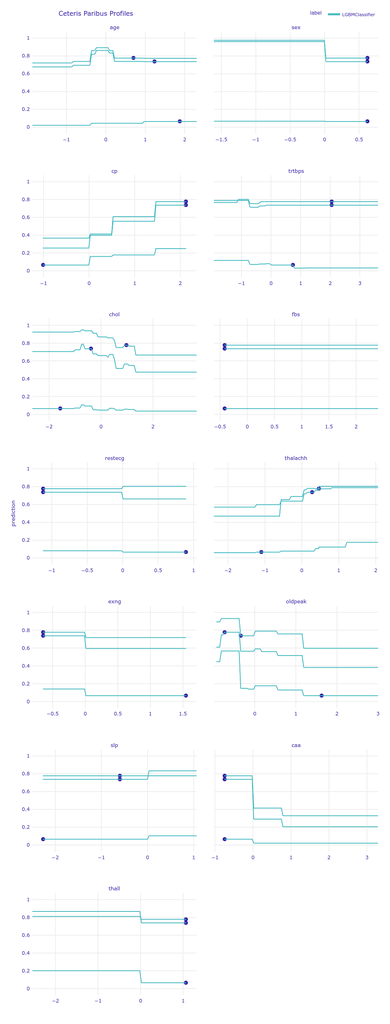

Exercise 2 answer: the explanations are more or less consistent across samples, we can see for example that cholesterol explanations exhibit significant variability. As this is a tree model, we can see smoothed discontinuities in the graphs.

# PDP

original model

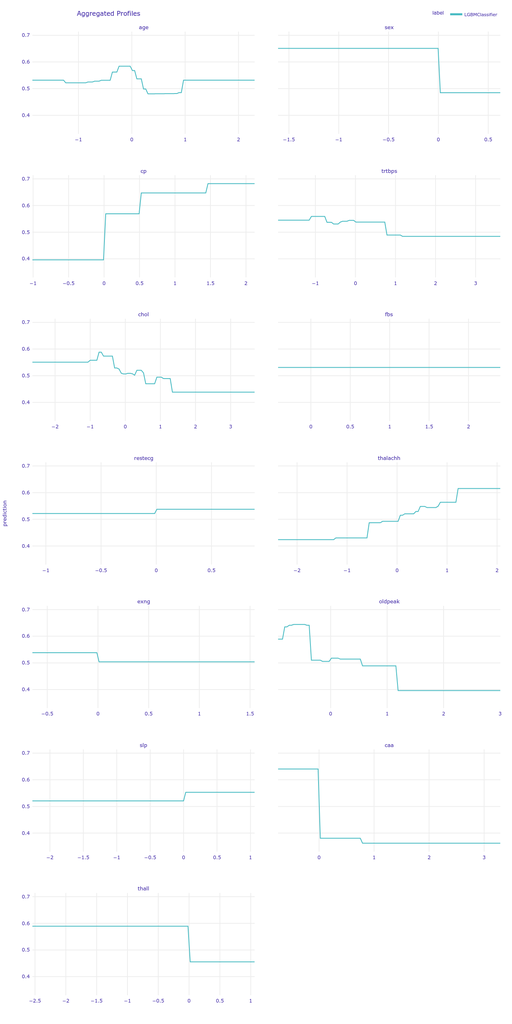

random forest

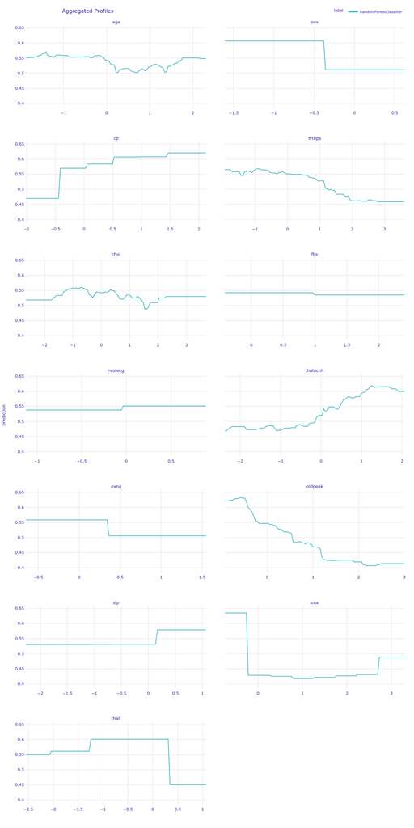